# Fraud Detection in Auto Insurance Claims

### Analysis Using Machine Learning Techniques

### Umair Chaanda

The main goal of this project is the implementation of various data mining and machine learning techniques and their applications. The exploration of multiple data analysis tasks on the targeted data, including both supervised knowledge discovery (predictive modeling) as well as unsupervised knowledge discovery for exploratory data analysis. The basic objective is to create a best predictive model for classifying fraud, whether a claimant is likely to commit fraud in auto insurance claims. This is a pure classification task which also includes the misclassification costs. Accurate prediction of fraud in claims will lead to a number of benefits described above to several stakeholders.

## Import Packages

```python
from numpy import *
import numpy as np                                          # for carrying out efficient computations
from numpy import linalg as la
import pylab as pl
import pandas as pd                                         # for reading and writing spreadsheets
import pdb
import matplotlib.pyplot as plt                             # for displaying plots
import seaborn as sns                                       # for visualization of data
%matplotlib inline

from sklearn.model_selection import train_test_split        # for splitting data into train and test sets
from sklearn import preprocessing                           # for min-max normalization

from sklearn import neighbors                               # KNN Classifier
from sklearn.neighbors import KNeighborsClassifier          # KNeighborsClassifier
from sklearn import tree                                    # Decision tree Classifier
from sklearn.discriminant_analysis import LinearDiscriminantAnalysis # Linear Discriminant Analysis (LDA)
from sklearn import naive_bayes                             # Naive bayes classifier
from sklearn.neighbors import NearestCentroid               # Rocchio Classifier
from sklearn.ensemble import RandomForestClassifier         # Random Forest Classifier
from sklearn.ensemble import AdaBoostClassifier             # Ada Boost Classifier
from sklearn.ensemble import GradientBoostingClassifier     # Gradient Boosting Classifier
from sklearn.ensemble import BaggingClassifier              # Bagging Classifier
from sklearn.svm import SVC                                 # SVC Classifier (Support Vector Machines)
from sklearn.linear_model import LogisticRegression         # Logistic Regression Classifier

from sklearn.metrics import classification_report           # for classification report
from sklearn.metrics import confusion_matrix                # for confustion matrix

from sklearn.model_selection import cross_val_score, KFold  # k-fold cross validation

from sklearn.linear_model import LinearRegression           # standard multiple regression
from sklearn.linear_model import Lasso                      # L1 regularized regression
from sklearn.linear_model import Ridge                      # L2 regularized regression
from sklearn.linear_model import ElasticNet                 # combines the Lasso and Ridge
from sklearn.linear_model import SGDRegressor               # linear regression where SGD optimization is used to learn the model

from sklearn.cluster import KMeans                          # KMeans clustering function from sklearn.cluster
from sklearn import metrics                                 # Measure model performance
from sklearn.metrics import completeness_score, homogeneity_score

from sklearn import decomposition                           # PCA

from sklearn.naive_bayes import MultinomialNB
from sklearn.pipeline import Pipeline

from scipy.stats import sem

from sklearn.model_selection import GridSearchCV            # To optimize model parameters
```

```python
import warnings
warnings.filterwarnings('ignore')                           # ignore displaying the warnings
```

```python
%pylab inline
```

## Read Data File

The data used in this project is publicly-available and acquired from Kaggle. It contains information about historic claims and policy information. It has 39 columns including numerical, categorical and other types of variables with 1000 rows.

```python
claims = pd.read_csv("insurance_claims.csv", na_values=["?"])
                                       # missing values in csv file are listed as ?
                                       # Replace it with NaN in dataframe
print('Rows,', 'Columns')
print(claims.shape)                    # print number of rows and columns in data
claims.head()                          # see the first five rows in data
```

```
Rows, Columns
(1000, 39)
```

|  | months_as_customer | age | policy_number | policy_bind_date | policy_state | policy_csl | policy_deductable | policy_annual_premium | umbrella_limit | insured_zip | ... | witnesses | police_report_available | total_claim_amount | injury_claim | property_claim | vehicle_claim | auto_make | auto_model | auto_year | fraud_reported |
| --- | --- | --- | --- | --- | --- | --- | --- | --- | --- | --- | --- | --- | --- | --- | --- | --- | --- | --- | --- | --- | --- |
| 0 | 328 | 48 | 521585 | 17-10-2014 | OH | 250/500 | 1000 | 1406.91 | 0 | 466132 | ... | 2 | YES | 71610 | 6510 | 13020 | 52080 | Saab | 92x | 2004 | Y |
| 1 | 228 | 42 | 342868 | 27-06-2006 | IN | 250/500 | 2000 | 1197.22 | 5000000 | 468176 | ... | 0 | NaN | 5070 | 780 | 780 | 3510 | Mercedes | E400 | 2007 | Y |
| 2 | 134 | 29 | 687698 | 06-09-2000 | OH | 100/300 | 2000 | 1413.14 | 5000000 | 430632 | ... | 3 | NO | 34650 | 7700 | 3850 | 23100 | Dodge | RAM | 2007 | N |
| 3 | 256 | 41 | 227811 | 25-05-1990 | IL | 250/500 | 2000 | 1415.74 | 6000000 | 608117 | ... | 2 | NO | 63400 | 6340 | 6340 | 50720 | Chevrolet | Tahoe | 2014 | Y |
| 4 | 228 | 44 | 367455 | 06-06-2014 | IL | 500/1000 | 1000 | 1583.91 | 6000000 | 610706 | ... | 1 | NO | 6500 | 1300 | 650 | 4550 | Accura | RSX | 2009 | N |

5 rows × 39 columns

```python
claims.info()
```

```
<class 'pandas.core.frame.DataFrame'>
RangeIndex: 1000 entries, 0 to 999
Data columns (total 39 columns):
 #   Column                       Non-Null Count  Dtype
---  ------                       --------------  -----
 0   months_as_customer           1000 non-null   int64
 1   age                          1000 non-null   int64
 2   policy_number                1000 non-null   int64
 3   policy_bind_date             1000 non-null   object
 4   policy_state                 1000 non-null   object
 5   policy_csl                   1000 non-null   object
 6   policy_deductable            1000 non-null   int64
 7   policy_annual_premium        1000 non-null   float64
 8   umbrella_limit               1000 non-null   int64
 9   insured_zip                  1000 non-null   int64
```

[output cut: 31 more lines]

## Data Cleaning, Exploration/Visualization and Preprocessing

There are several data cleaning, data exploration and preprocessing steps will be performed as part of the project.

### General information about the data and Examine and handle the missing data

```python
# display general information about the data set
# good way to check if any features have null values and the levels of categorical variables
pd.DataFrame({'Dtype':claims.dtypes,
              'Levels':[claims[x].unique() for x in claims.columns],
              'Null_Count':claims.isna().sum(),
              'Number_Unique_Values':claims.nunique()
             })
```

|  | Dtype | Levels | Null_Count | Number_Unique_Values |
| --- | --- | --- | --- | --- |
| months_as_customer | int64 | [328, 228, 134, 256, 137, 165, 27, 212, 235, 4... | 0 | 391 |
| age | int64 | [48, 42, 29, 41, 44, 39, 34, 37, 33, 61, 23, 3... | 0 | 46 |
| policy_number | int64 | [521585, 342868, 687698, 227811, 367455, 10459... | 0 | 1000 |
| policy_bind_date | object | [17-10-2014, 27-06-2006, 06-09-2000, 25-05-199... | 0 | 951 |
| policy_state | object | [OH, IN, IL] | 0 | 3 |
| policy_csl | object | [250/500, 100/300, 500/1000] | 0 | 3 |
| policy_deductable | int64 | [1000, 2000, 500] | 0 | 3 |
| policy_annual_premium | float64 | [1406.91, 1197.22, 1413.14, 1415.74, 1583.91, ... | 0 | 991 |
| umbrella_limit | int64 | [0, 5000000, 6000000, 4000000, 3000000, 800000... | 0 | 11 |
| insured_zip | int64 | [466132, 468176, 430632, 608117, 610706, 47845... | 0 | 995 |
| insured_sex | object | [MALE, FEMALE] | 0 | 2 |
| insured_education_level | object | [MD, PhD, Associate, Masters, High School, Col... | 0 | 7 |
| insured_occupation | object | [craft-repair, machine-op-inspct, sales, armed... | 0 | 14 |
| insured_hobbies | object | [sleeping, reading, board-games, bungie-jumpin... | 0 | 20 |
| insured_relationship | object | [husband, other-relative, own-child, unmarried... | 0 | 6 |
| capital-gains | int64 | [53300, 0, 35100, 48900, 66000, 38400, 52800, ... | 0 | 338 |
| capital-loss | int64 | [0, -62400, -46000, -77000, -39300, -51000, -3... | 0 | 354 |
| incident_date | object | [25-01-2015, 21-01-2015, 22-02-2015, 10-01-201... | 0 | 60 |
| incident_type | object | [Single Vehicle Collision, Vehicle Theft, Mult... | 0 | 4 |
| collision_type | object | [Side Collision, nan, Rear Collision, Front Co... | 178 | 3 |
| incident_severity | object | [Major Damage, Minor Damage, Total Loss, Trivi... | 0 | 4 |
| authorities_contacted | object | [Police, None, Fire, Other, Ambulance] | 0 | 5 |
| incident_state | object | [SC, VA, NY, OH, WV, NC, PA] | 0 | 7 |
| incident_city | object | [Columbus, Riverwood, Arlington, Springfield, ... | 0 | 7 |
| incident_location | object | [9935 4th Drive, 6608 MLK Hwy, 7121 Francis La... | 0 | 1000 |
| incident_hour_of_the_day | int64 | [5, 8, 7, 20, 19, 0, 23, 21, 14, 22, 9, 12, 15... | 0 | 24 |
| number_of_vehicles_involved | int64 | [1, 3, 4, 2] | 0 | 4 |
| property_damage | object | [YES, nan, NO] | 360 | 2 |
| bodily_injuries | int64 | [1, 0, 2] | 0 | 3 |
| witnesses | int64 | [2, 0, 3, 1] | 0 | 4 |
| police_report_available | object | [YES, nan, NO] | 343 | 2 |
| total_claim_amount | int64 | [71610, 5070, 34650, 63400, 6500, 64100, 78650... | 0 | 763 |
| injury_claim | int64 | [6510, 780, 7700, 6340, 1300, 6410, 21450, 938... | 0 | 638 |
| property_claim | int64 | [13020, 780, 3850, 6340, 650, 6410, 7150, 9380... | 0 | 626 |
| vehicle_claim | int64 | [52080, 3510, 23100, 50720, 4550, 51280, 50050... | 0 | 726 |
| auto_make | object | [Saab, Mercedes, Dodge, Chevrolet, Accura, Nis... | 0 | 14 |
| auto_model | object | [92x, E400, RAM, Tahoe, RSX, 95, Pathfinder, A... | 0 | 39 |
| auto_year | int64 | [2004, 2007, 2014, 2009, 2003, 2012, 2015, 199... | 0 | 21 |
| fraud_reported | object | [Y, N] | 0 | 2 |

### Basic Statistics of Features:

Let's explore the general characteristics of the data as a whole: examine the means, standard deviations, and other statistics associated with the numerical attributes.

```python
# summary of the distribution of features
claims.describe(include="all").T
```

|  | count | unique | top | freq | mean | std | min | 25% | 50% | 75% | max |
| --- | --- | --- | --- | --- | --- | --- | --- | --- | --- | --- | --- |
| months_as_customer | 1000 | NaN | NaN | NaN | 203.954 | 115.113 | 0 | 115.75 | 199.5 | 276.25 | 479 |
| age | 1000 | NaN | NaN | NaN | 38.948 | 9.14029 | 19 | 32 | 38 | 44 | 64 |
| policy_number | 1000 | NaN | NaN | NaN | 546239 | 257063 | 100804 | 335980 | 533135 | 759100 | 999435 |
| policy_bind_date | 1000 | 951 | 05-08-1992 | 3 | NaN | NaN | NaN | NaN | NaN | NaN | NaN |
| policy_state | 1000 | 3 | OH | 352 | NaN | NaN | NaN | NaN | NaN | NaN | NaN |
| policy_csl | 1000 | 3 | 250/500 | 351 | NaN | NaN | NaN | NaN | NaN | NaN | NaN |
| policy_deductable | 1000 | NaN | NaN | NaN | 1136 | 611.865 | 500 | 500 | 1000 | 2000 | 2000 |
| policy_annual_premium | 1000 | NaN | NaN | NaN | 1256.41 | 244.167 | 433.33 | 1089.61 | 1257.2 | 1415.69 | 2047.59 |
| umbrella_limit | 1000 | NaN | NaN | NaN | 1.101e+06 | 2.29741e+06 | -1e+06 | 0 | 0 | 0 | 1e+07 |
| insured_zip | 1000 | NaN | NaN | NaN | 501214 | 71701.6 | 430104 | 448404 | 466446 | 603251 | 620962 |
| insured_sex | 1000 | 2 | FEMALE | 537 | NaN | NaN | NaN | NaN | NaN | NaN | NaN |
| insured_education_level | 1000 | 7 | JD | 161 | NaN | NaN | NaN | NaN | NaN | NaN | NaN |
| insured_occupation | 1000 | 14 | machine-op-inspct | 93 | NaN | NaN | NaN | NaN | NaN | NaN | NaN |
| insured_hobbies | 1000 | 20 | reading | 64 | NaN | NaN | NaN | NaN | NaN | NaN | NaN |
| insured_relationship | 1000 | 6 | own-child | 183 | NaN | NaN | NaN | NaN | NaN | NaN | NaN |
| capital-gains | 1000 | NaN | NaN | NaN | 25126.1 | 27872.2 | 0 | 0 | 0 | 51025 | 100500 |
| capital-loss | 1000 | NaN | NaN | NaN | -26793.7 | 28104.1 | -111100 | -51500 | -23250 | 0 | 0 |
| incident_date | 1000 | 60 | 02-02-2015 | 28 | NaN | NaN | NaN | NaN | NaN | NaN | NaN |
| incident_type | 1000 | 4 | Multi-vehicle Collision | 419 | NaN | NaN | NaN | NaN | NaN | NaN | NaN |
| collision_type | 822 | 3 | Rear Collision | 292 | NaN | NaN | NaN | NaN | NaN | NaN | NaN |
| incident_severity | 1000 | 4 | Minor Damage | 354 | NaN | NaN | NaN | NaN | NaN | NaN | NaN |
| authorities_contacted | 1000 | 5 | Police | 292 | NaN | NaN | NaN | NaN | NaN | NaN | NaN |
| incident_state | 1000 | 7 | NY | 262 | NaN | NaN | NaN | NaN | NaN | NaN | NaN |
| incident_city | 1000 | 7 | Springfield | 157 | NaN | NaN | NaN | NaN | NaN | NaN | NaN |
| incident_location | 1000 | 1000 | 2063 Weaver St | 1 | NaN | NaN | NaN | NaN | NaN | NaN | NaN |
| incident_hour_of_the_day | 1000 | NaN | NaN | NaN | 11.644 | 6.95137 | 0 | 6 | 12 | 17 | 23 |
| number_of_vehicles_involved | 1000 | NaN | NaN | NaN | 1.839 | 1.01888 | 1 | 1 | 1 | 3 | 4 |
| property_damage | 640 | 2 | NO | 338 | NaN | NaN | NaN | NaN | NaN | NaN | NaN |
| bodily_injuries | 1000 | NaN | NaN | NaN | 0.992 | 0.820127 | 0 | 0 | 1 | 2 | 2 |
| witnesses | 1000 | NaN | NaN | NaN | 1.487 | 1.11134 | 0 | 1 | 1 | 2 | 3 |
| police_report_available | 657 | 2 | NO | 343 | NaN | NaN | NaN | NaN | NaN | NaN | NaN |
| total_claim_amount | 1000 | NaN | NaN | NaN | 52761.9 | 26401.5 | 100 | 41812.5 | 58055 | 70592.5 | 114920 |
| injury_claim | 1000 | NaN | NaN | NaN | 7433.42 | 4880.95 | 0 | 4295 | 6775 | 11305 | 21450 |
| property_claim | 1000 | NaN | NaN | NaN | 7399.57 | 4824.73 | 0 | 4445 | 6750 | 10885 | 23670 |
| vehicle_claim | 1000 | NaN | NaN | NaN | 37928.9 | 18886.3 | 70 | 30292.5 | 42100 | 50822.5 | 79560 |
| auto_make | 1000 | 14 | Suburu | 80 | NaN | NaN | NaN | NaN | NaN | NaN | NaN |
| auto_model | 1000 | 39 | RAM | 43 | NaN | NaN | NaN | NaN | NaN | NaN | NaN |
| auto_year | 1000 | NaN | NaN | NaN | 2005.1 | 6.01586 | 1995 | 2000 | 2005 | 2010 | 2015 |
| fraud_reported | 1000 | 2 | N | 753 | NaN | NaN | NaN | NaN | NaN | NaN | NaN |

After reading the csv dataset into a Dataframe in python, the first step was to look at the general information about the data such as feature names and their types, missing values, number of unique values and the categorical levels for each feature. The second step was to look at the basic statistics of features to explore the general characteristics of the data as a whole: examine the means, standard deviations, and other statistics associated with the numerical attributes.

### Discretization - Convert numerical attributes into categorical attributes

Data discretization is defined as a process of converting continuous data attribute values into a finite set of intervals and associating with each interval some specific data value.

```python
# make a copy of original dataframe
claims_clean = claims.copy()
```

```python
# incident_hour_of_the_day has 24 unique values
# Discretize the incident_hour_of_the_day attribute into 3 categories (corresponding to 'Morning', 'Afternoon', 'Evening')
claims_clean['incident_part_of_the_day'] = pd.cut(claims_clean.incident_hour_of_the_day,bins=[0, 11, 17, 23],
                                                  labels=['Morning', 'Afternoon', 'Evening'], include_lowest=True)
```

The attribute (incident_hour_of_the_day) had 24 uniques values and it was not suitable to treat this variable as numerical so we discretized the incident_hour_of_the_day attribute into 3 categories corresponding to 'Morning', 'Afternoon', 'Evening' (bins=[0, 11, 17, 23]) using pandas pd.cut function.

### Convert Some Variables Types:

In many situations, we need to convert variables from one type into another. Type conversion is a method of changing features from one data type to another. An example of typecasting is converting an integer to a string.

```python
# convert these variables from int64 into object
int_list = ['policy_deductable', 'number_of_vehicles_involved',
            'bodily_injuries', 'witnesses']

# policy_deductable, number_of_vehicles_involved, bodily_injuries, witnesses
claims_clean[int_list] = claims_clean[int_list].astype(str)

# convert policy_annual_premium from float to int64
claims_clean['policy_annual_premium'] = claims_clean['policy_annual_premium'].astype(int64)
```

The features ('policy_deductable', 'number_of_vehicles_involved', 'bodily_injuries', and 'witnesses') had very few unique values and they are actually categorical in nature so we converted the data type of these features from int64 into objects. We also converted the feature (‘policy_annual_premium’) from float to int64 for efficient computation.

### Handling Missing Data and Dropping some Features:

```python
# drop variables which are not going to be used in our analysis based on above information
drop_col = ['policy_number', 'policy_bind_date', 'insured_zip',
            'incident_date', 'collision_type', 'incident_location',
            'property_damage', 'police_report_available', 'auto_model',
            'incident_hour_of_the_day']
claims_clean.drop(columns=drop_col, inplace=True)                 # inplace=True permanently changes the dataframe
```

- The total number of rows in the data are 1000 and there are three features which have a very large number of rows with missing values
- Those features are collision_type, property_damage, and policy_report_available. These are categorical attributes so instead of removing a very large number of rows from the data, we are just going to drop these three columns.

### General Information on the Cleaned dataset:

```python
# this is the reduced number of features in the data
print(claims_clean.shape)
```

```
(1000, 30)
```

```python
# display general information about the data set
# good way to check if any features have null values and the levels of categorical variables
pd.DataFrame({'Dtype':claims_clean.dtypes,
              'Levels':[claims_clean[x].unique() for x in claims_clean.columns],
              'Null_Count':claims_clean.isna().sum(),
              'Number_Unique_Values':claims_clean.nunique()
             })
```

|  | Dtype | Levels | Null_Count | Number_Unique_Values |
| --- | --- | --- | --- | --- |
| months_as_customer | int64 | [328, 228, 134, 256, 137, 165, 27, 212, 235, 4... | 0 | 391 |
| age | int64 | [48, 42, 29, 41, 44, 39, 34, 37, 33, 61, 23, 3... | 0 | 46 |
| policy_state | object | [OH, IN, IL] | 0 | 3 |
| policy_csl | object | [250/500, 100/300, 500/1000] | 0 | 3 |
| policy_deductable | object | [1000, 2000, 500] | 0 | 3 |
| policy_annual_premium | int64 | [1406, 1197, 1413, 1415, 1583, 1351, 1333, 113... | 0 | 612 |
| umbrella_limit | int64 | [0, 5000000, 6000000, 4000000, 3000000, 800000... | 0 | 11 |
| insured_sex | object | [MALE, FEMALE] | 0 | 2 |
| insured_education_level | object | [MD, PhD, Associate, Masters, High School, Col... | 0 | 7 |
| insured_occupation | object | [craft-repair, machine-op-inspct, sales, armed... | 0 | 14 |
| insured_hobbies | object | [sleeping, reading, board-games, bungie-jumpin... | 0 | 20 |
| insured_relationship | object | [husband, other-relative, own-child, unmarried... | 0 | 6 |
| capital-gains | int64 | [53300, 0, 35100, 48900, 66000, 38400, 52800, ... | 0 | 338 |
| capital-loss | int64 | [0, -62400, -46000, -77000, -39300, -51000, -3... | 0 | 354 |
| incident_type | object | [Single Vehicle Collision, Vehicle Theft, Mult... | 0 | 4 |
| incident_severity | object | [Major Damage, Minor Damage, Total Loss, Trivi... | 0 | 4 |
| authorities_contacted | object | [Police, None, Fire, Other, Ambulance] | 0 | 5 |
| incident_state | object | [SC, VA, NY, OH, WV, NC, PA] | 0 | 7 |
| incident_city | object | [Columbus, Riverwood, Arlington, Springfield, ... | 0 | 7 |
| number_of_vehicles_involved | object | [1, 3, 4, 2] | 0 | 4 |
| bodily_injuries | object | [1, 0, 2] | 0 | 3 |
| witnesses | object | [2, 0, 3, 1] | 0 | 4 |
| total_claim_amount | int64 | [71610, 5070, 34650, 63400, 6500, 64100, 78650... | 0 | 763 |
| injury_claim | int64 | [6510, 780, 7700, 6340, 1300, 6410, 21450, 938... | 0 | 638 |
| property_claim | int64 | [13020, 780, 3850, 6340, 650, 6410, 7150, 9380... | 0 | 626 |
| vehicle_claim | int64 | [52080, 3510, 23100, 50720, 4550, 51280, 50050... | 0 | 726 |
| auto_make | object | [Saab, Mercedes, Dodge, Chevrolet, Accura, Nis... | 0 | 14 |
| auto_year | int64 | [2004, 2007, 2014, 2009, 2003, 2012, 2015, 199... | 0 | 21 |
| fraud_reported | object | [Y, N] | 0 | 2 |
| incident_part_of_the_day | category | [Morning, Evening, Afternoon] Categories (3, o... | 0 | 3 |

The total number of rows and columns in the cleaned data 1000 x 30. We can see in the table that there are no missing values in the data and all the features are converted into appropriate types.

### Basic statistics of features on cleaned data:

Let's explore the general characteristics of the data as a whole: examine the means, standard deviations, and other statistics associated with the numerical attributes.

```python
# summary of the distribution of features
claims_clean.describe(include="all").T
```

|  | count | unique | top | freq | mean | std | min | 25% | 50% | 75% | max |
| --- | --- | --- | --- | --- | --- | --- | --- | --- | --- | --- | --- |
| months_as_customer | 1000 | NaN | NaN | NaN | 203.954 | 115.113 | 0 | 115.75 | 199.5 | 276.25 | 479 |
| age | 1000 | NaN | NaN | NaN | 38.948 | 9.14029 | 19 | 32 | 38 | 44 | 64 |
| policy_state | 1000 | 3 | OH | 352 | NaN | NaN | NaN | NaN | NaN | NaN | NaN |
| policy_csl | 1000 | 3 | 250/500 | 351 | NaN | NaN | NaN | NaN | NaN | NaN | NaN |
| policy_deductable | 1000 | 3 | 1000 | 351 | NaN | NaN | NaN | NaN | NaN | NaN | NaN |
| policy_annual_premium | 1000 | NaN | NaN | NaN | 1255.91 | 244.145 | 433 | 1089.5 | 1257 | 1415 | 2047 |
| umbrella_limit | 1000 | NaN | NaN | NaN | 1.101e+06 | 2.29741e+06 | -1e+06 | 0 | 0 | 0 | 1e+07 |
| insured_sex | 1000 | 2 | FEMALE | 537 | NaN | NaN | NaN | NaN | NaN | NaN | NaN |
| insured_education_level | 1000 | 7 | JD | 161 | NaN | NaN | NaN | NaN | NaN | NaN | NaN |
| insured_occupation | 1000 | 14 | machine-op-inspct | 93 | NaN | NaN | NaN | NaN | NaN | NaN | NaN |
| insured_hobbies | 1000 | 20 | reading | 64 | NaN | NaN | NaN | NaN | NaN | NaN | NaN |
| insured_relationship | 1000 | 6 | own-child | 183 | NaN | NaN | NaN | NaN | NaN | NaN | NaN |
| capital-gains | 1000 | NaN | NaN | NaN | 25126.1 | 27872.2 | 0 | 0 | 0 | 51025 | 100500 |
| capital-loss | 1000 | NaN | NaN | NaN | -26793.7 | 28104.1 | -111100 | -51500 | -23250 | 0 | 0 |
| incident_type | 1000 | 4 | Multi-vehicle Collision | 419 | NaN | NaN | NaN | NaN | NaN | NaN | NaN |
| incident_severity | 1000 | 4 | Minor Damage | 354 | NaN | NaN | NaN | NaN | NaN | NaN | NaN |
| authorities_contacted | 1000 | 5 | Police | 292 | NaN | NaN | NaN | NaN | NaN | NaN | NaN |
| incident_state | 1000 | 7 | NY | 262 | NaN | NaN | NaN | NaN | NaN | NaN | NaN |
| incident_city | 1000 | 7 | Springfield | 157 | NaN | NaN | NaN | NaN | NaN | NaN | NaN |
| number_of_vehicles_involved | 1000 | 4 | 1 | 581 | NaN | NaN | NaN | NaN | NaN | NaN | NaN |
| bodily_injuries | 1000 | 3 | 0 | 340 | NaN | NaN | NaN | NaN | NaN | NaN | NaN |
| witnesses | 1000 | 4 | 1 | 258 | NaN | NaN | NaN | NaN | NaN | NaN | NaN |
| total_claim_amount | 1000 | NaN | NaN | NaN | 52761.9 | 26401.5 | 100 | 41812.5 | 58055 | 70592.5 | 114920 |
| injury_claim | 1000 | NaN | NaN | NaN | 7433.42 | 4880.95 | 0 | 4295 | 6775 | 11305 | 21450 |
| property_claim | 1000 | NaN | NaN | NaN | 7399.57 | 4824.73 | 0 | 4445 | 6750 | 10885 | 23670 |
| vehicle_claim | 1000 | NaN | NaN | NaN | 37928.9 | 18886.3 | 70 | 30292.5 | 42100 | 50822.5 | 79560 |
| auto_make | 1000 | 14 | Suburu | 80 | NaN | NaN | NaN | NaN | NaN | NaN | NaN |
| auto_year | 1000 | NaN | NaN | NaN | 2005.1 | 6.01586 | 1995 | 2000 | 2005 | 2010 | 2015 |
| fraud_reported | 1000 | 2 | N | 753 | NaN | NaN | NaN | NaN | NaN | NaN | NaN |
| incident_part_of_the_day | 1000 | 3 | Morning | 483 | NaN | NaN | NaN | NaN | NaN | NaN | NaN |

The target feature (‘fraud_reported’) has a class imbalance (N=No Fraud Reported has 753 instances) whereas (Y=Yes Fraud Reported has 247 instances). Above is the table which displays the total count of instances, number of unique features, top categorical value and frequency of that value, and some statistical measures such as Standard Deviation, Minimum value, 25% percentile, 50% percentile, 75% percentile, and the maximum value of each feature.

## Visualization of Data

### Distribution of all categorical features in the data

Show the distributions of values associated with categorical attributes using SEABORN package and/or plotting capabilities of Pandas to generate bar charts showing the distribution of categories for each attribute).

```python
# extract names of the categorical features in the data
categorical = claims_clean.select_dtypes(exclude=['float','int64']).columns
print(categorical)
```

```
Index(['policy_state', 'policy_csl', 'policy_deductable', 'insured_sex',
       'insured_education_level', 'insured_occupation', 'insured_hobbies',
       'insured_relationship', 'incident_type', 'incident_severity',
       'authorities_contacted', 'incident_state', 'incident_city',
       'number_of_vehicles_involved', 'bodily_injuries', 'witnesses',
       'auto_make', 'fraud_reported', 'incident_part_of_the_day'],
      dtype='object')
```

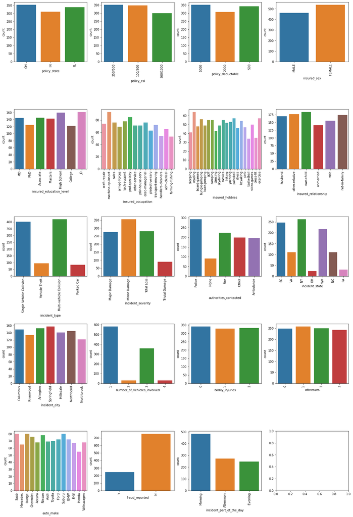

```python
fig, ax = plt.subplots(5, 4, figsize=(20, 30))
fig.subplots_adjust(hspace=0.8, wspace=0.2)

for variable, subplot in zip(categorical, ax.flatten()):
    sns.countplot(claims_clean[variable], ax=subplot)
    for label in subplot.get_xticklabels():
        label.set_rotation(90)
```

### Cross Tabulated View using Barplots - Comparing categorical attributes with respect to target attribute (fraud_reported)

Perform a cross-tabulation of all categorical attributes with the target attribute (fraud_reported). This requires the aggregation of the occurrences of each fraud_reported value (Y or N) separately for each value of the other attributes. Here, we are using SEABORN visualization package to create bar charts graphs to visualize of the relationships between these sets of variables.

```python
categorical2 = ['policy_state', 'policy_csl', 'policy_deductable', 'insured_sex',
                'insured_education_level', 'insured_relationship', 'incident_type',
                'incident_severity', 'authorities_contacted', 'incident_state',
                'incident_city', 'number_of_vehicles_involved', 'bodily_injuries',
                'witnesses', 'auto_make', 'incident_part_of_the_day']
```

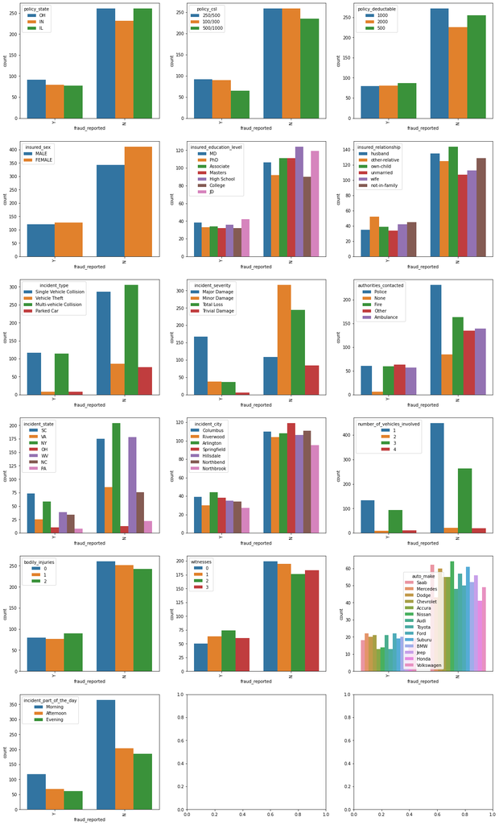

```python
fig, ax = plt.subplots(6, 3, figsize=(20, 35))
fig.subplots_adjust(hspace=0.2, wspace=0.2)

for variable, subplot in zip(categorical2, ax.flatten()):
    sns.countplot(claims_clean['fraud_reported'], hue=variable, data=claims_clean, ax=subplot)
    for label in subplot.get_xticklabels():
        label.set_rotation(90)
```

Following are some of the key points observed from these visualizations:

### Visualize Numerical Attributes

Let's visualize some of the numerical attributes using pairplot function from SEABORN package:

A pairplot plots a pairwise relationships in a dataset which shows the Correlation between numerical attributes and it also displays the distributions of all attributes.

```python
numerical1 = ['months_as_customer', 'age', 'policy_annual_premium', 'capital-gains', 'capital-loss', 'auto_year']
numerical2 = ['total_claim_amount', 'injury_claim', 'property_claim', 'vehicle_claim']
```

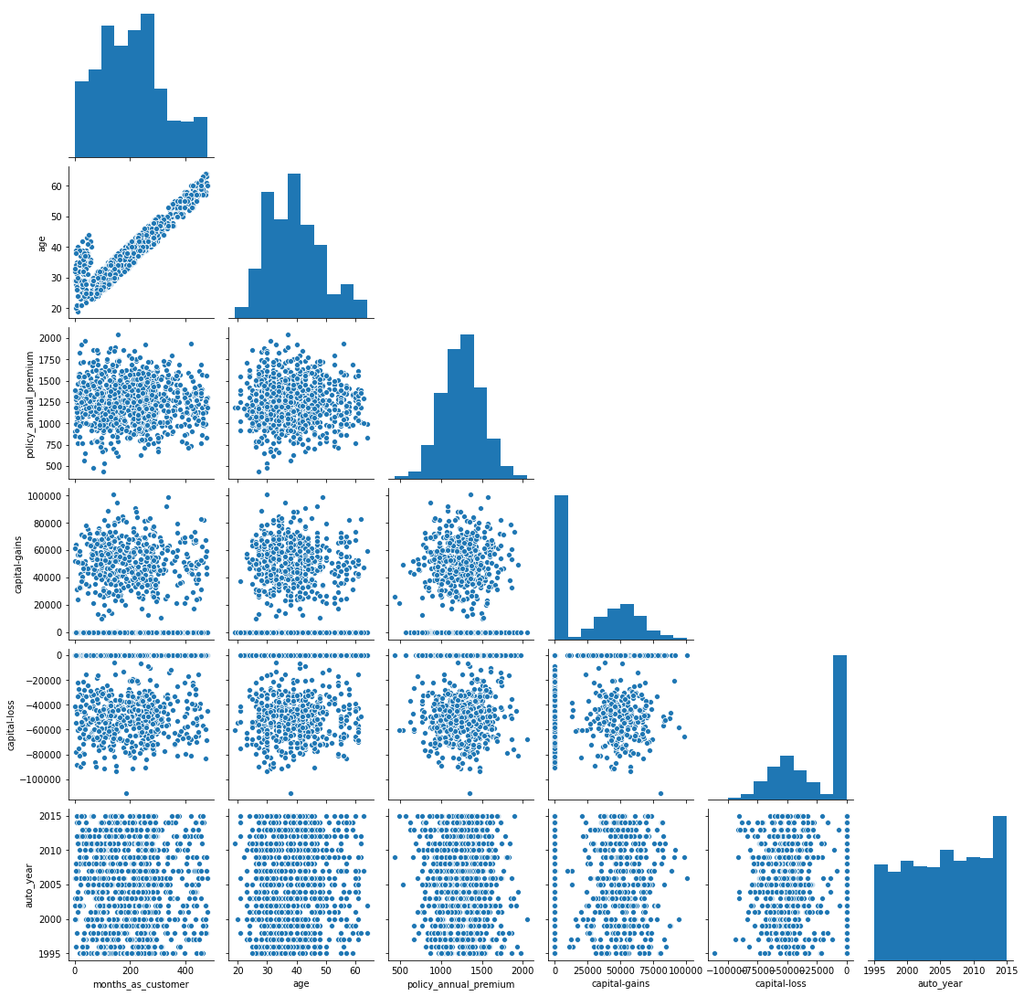

```python
sns.pairplot(claims_clean[numerical1], corner=True)
```

For this group of variables, we can see that the feature ‘age’ has a strong positive linear relationship with months_as_customer. There don't appear to be any significant outliers in this plot. However, if we look at the other features, there do not seem to be any positive or negative relationships among them so we are not too much concerned about the multicollinearity in the data.

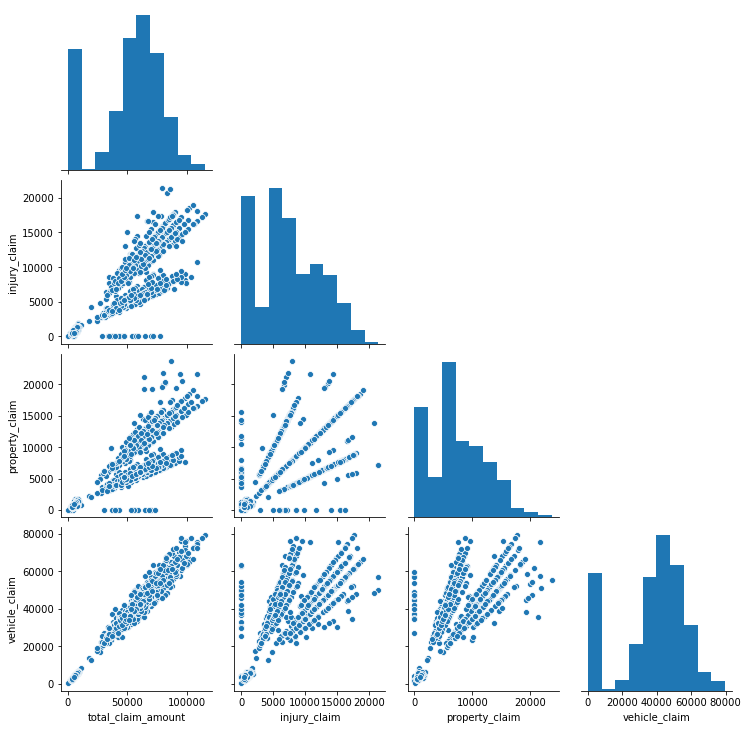

```python
sns.pairplot(claims_clean[numerical2], corner=True)
```

If we look at this group of features (total_claim_amount, injucy_claim, property_claim, vehicle_claim), they definitely have strong positive relationships among them. One of the reasons is that the total_claim_amount is the sum of injury_claim, property_claim, and vehicle_claim.

### Correlations Analysis

Using the numeric attributes, lets perform basic correlation analysis among the attributes. The following Complete Correlation Matrix shows any significant positive or negative correlations among pairs of attributes.

- A correlation matrix is a table showing correlation coefficients between sets of variables.
- Correlation analysis is a very important step in pre-processing because it helps in identifying multicollinearity and building components in Principle Components Analysis (PCA).

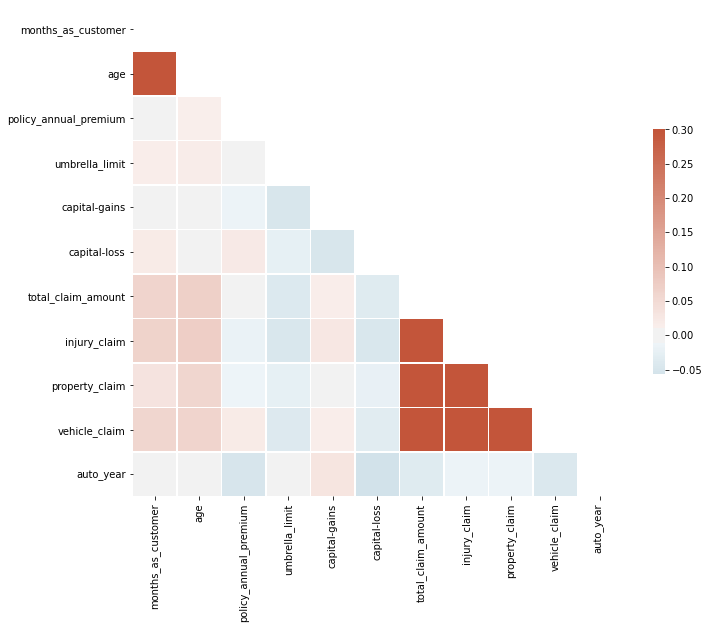

```python
# Compute the correlation matrix
corr = claims_clean.corr()

# Generate a mask for the upper triangle
mask = np.triu(np.ones_like(corr, dtype=bool))

# Set up the matplotlib figure
f, ax = plt.subplots(figsize=(11, 9))

# Generate a custom diverging colormap
cmap = sns.diverging_palette(230, 20, as_cmap=True)

# Draw the heatmap with the mask and correct aspect ratio
sns.heatmap(corr, mask=mask, cmap=cmap, vmax=.3, center=0,
            square=True, linewidths=.5, cbar_kws={"shrink": .5})
```

The features that seem Strong Positively Correlated are (total_claim_amount, injucy_claim, property_claim, vehicle_claim). This is definitely a distinct group (orange squared boxes) of features. This group is the same set of features which we identified above in the scatterplot matrix.

### Let's separate the target attribute ("fraud_reported") and the attributes used for model training¶

The next step after cleaning and exploration of variables is to separate the target attribute ("fraud_reported") and the attributes used for model training. Let's create a separate data frame which contains the records without target attribute. Then pull the target attribute and store it separately.

```python
# records without target attribute
claims_records = claims_clean.drop('fraud_reported', 1)
claims_records.head()
```

|  | months_as_customer | age | policy_state | policy_csl | policy_deductable | policy_annual_premium | umbrella_limit | insured_sex | insured_education_level | insured_occupation | ... | number_of_vehicles_involved | bodily_injuries | witnesses | total_claim_amount | injury_claim | property_claim | vehicle_claim | auto_make | auto_year | incident_part_of_the_day |
| --- | --- | --- | --- | --- | --- | --- | --- | --- | --- | --- | --- | --- | --- | --- | --- | --- | --- | --- | --- | --- | --- |
| 0 | 328 | 48 | OH | 250/500 | 1000 | 1406 | 0 | MALE | MD | craft-repair | ... | 1 | 1 | 2 | 71610 | 6510 | 13020 | 52080 | Saab | 2004 | Morning |
| 1 | 228 | 42 | IN | 250/500 | 2000 | 1197 | 5000000 | MALE | MD | machine-op-inspct | ... | 1 | 0 | 0 | 5070 | 780 | 780 | 3510 | Mercedes | 2007 | Morning |
| 2 | 134 | 29 | OH | 100/300 | 2000 | 1413 | 5000000 | FEMALE | PhD | sales | ... | 3 | 2 | 3 | 34650 | 7700 | 3850 | 23100 | Dodge | 2007 | Morning |
| 3 | 256 | 41 | IL | 250/500 | 2000 | 1415 | 6000000 | FEMALE | PhD | armed-forces | ... | 1 | 1 | 2 | 63400 | 6340 | 6340 | 50720 | Chevrolet | 2014 | Morning |
| 4 | 228 | 44 | IL | 500/1000 | 1000 | 1583 | 6000000 | MALE | Associate | sales | ... | 1 | 0 | 1 | 6500 | 1300 | 650 | 4550 | Accura | 2009 | Evening |

5 rows × 29 columns

```python
# Pull target attribute
# Let's separate the target attribute ("fraud_reported") from the attributes used for training
claims_target = claims_clean.fraud_reported
claims_target.head()
```

```
0    Y
1    Y
2    N
3    Y
4    N
Name: fraud_reported, dtype: object
```

### Split the data into training and test sets (using 80%-20% randomized split). Note that the same split should also be performed on the target attribute).

- Create a 20%-80% randomized split of the data. Set aside the 20% test portion; the 80% training data partition will be used for cross-validation on various tasks specified below.
- We divide the data into randomized training and test partitions (note that the same split should also be perfromed on the target attribute). The easiest way to do this is to use the "train_test_split" module of "sklearn.cross_validation".

```python
x_train, x_test, y_train, y_test = train_test_split(claims_records, claims_target, test_size=0.2, random_state=33)
```

```python
print(x_train.shape)
print(y_train.shape)
print(x_test.shape)
print(y_test.shape)
```

```
(800, 29)
(800,)
(200, 29)
(200,)
```

### Performing min-max normalization to rescale numeric features

Let's use scikit learn preprocessing package for Min-Max Normalization to transform the values of all numeric attributes in the table onto the range 0.0-1.0. Fit the MinMaxScaler on the training data first and then transform the training and test data using this scaler.

```python
# names of the numerical features
nums = ['months_as_customer', 'age', 'policy_annual_premium',
        'umbrella_limit', 'capital-gains', 'capital-loss',
        'auto_year', 'total_claim_amount', 'injury_claim',
        'property_claim', 'vehicle_claim']
```

```python
# fit the MinMaxScaler on the training data
min_max_scaler = preprocessing.MinMaxScaler().fit(x_train[nums])

x_train[nums] = min_max_scaler.transform(x_train[nums])    # transform the training data using above scaler
x_test[nums] = min_max_scaler.transform(x_test[nums])      # transform the test data using above scaler
```

```python
# Let's look at the normalized training data
np.set_printoptions(precision=2, linewidth=80, suppress=True)
x_train.head()
```

|  | months_as_customer | age | policy_state | policy_csl | policy_deductable | policy_annual_premium | umbrella_limit | insured_sex | insured_education_level | insured_occupation | ... | number_of_vehicles_involved | bodily_injuries | witnesses | total_claim_amount | injury_claim | property_claim | vehicle_claim | auto_make | auto_year | incident_part_of_the_day |
| --- | --- | --- | --- | --- | --- | --- | --- | --- | --- | --- | --- | --- | --- | --- | --- | --- | --- | --- | --- | --- | --- |
| 866 | 0.317328 | 0.311111 | IN | 100/300 | 1000 | 0.372367 | 0.090909 | FEMALE | JD | armed-forces | ... | 1 | 1 | 0 | 0.548496 | 0.331002 | 0.299958 | 0.617768 | Accura | 0.95 | Evening |
| 909 | 0.400835 | 0.422222 | IN | 500/1000 | 1000 | 0.525403 | 0.090909 | FEMALE | Masters | transport-moving | ... | 3 | 0 | 2 | 0.254690 | 0.143124 | 0.259400 | 0.256656 | Jeep | 0.75 | Morning |
| 640 | 0.379958 | 0.422222 | OH | 500/1000 | 2000 | 0.624535 | 0.090909 | FEMALE | Masters | armed-forces | ... | 1 | 2 | 3 | 0.776372 | 0.379953 | 0.688635 | 0.816180 | Dodge | 0.50 | Evening |
| 582 | 0.271399 | 0.200000 | OH | 500/1000 | 1000 | 0.353160 | 0.090909 | FEMALE | JD | farming-fishing | ... | 2 | 2 | 1 | 0.735398 | 0.609790 | 0.552598 | 0.735023 | Ford | 0.75 | Evening |
| 516 | 0.135699 | 0.177778 | IN | 100/300 | 1000 | 0.452912 | 0.090909 | FEMALE | College | adm-clerical | ... | 1 | 1 | 2 | 0.362124 | 0.166434 | 0.301648 | 0.392857 | Chevrolet | 0.45 | Afternoon |

5 rows × 29 columns

```python
# Let's look at the normalized test data
np.set_printoptions(precision=2, linewidth=80, suppress=True)
x_test.head()
```

|  | months_as_customer | age | policy_state | policy_csl | policy_deductable | policy_annual_premium | umbrella_limit | insured_sex | insured_education_level | insured_occupation | ... | number_of_vehicles_involved | bodily_injuries | witnesses | total_claim_amount | injury_claim | property_claim | vehicle_claim | auto_make | auto_year | incident_part_of_the_day |
| --- | --- | --- | --- | --- | --- | --- | --- | --- | --- | --- | --- | --- | --- | --- | --- | --- | --- | --- | --- | --- | --- |
| 286 | 0.340292 | 0.266667 | IN | 100/300 | 1000 | 0.353779 | 0.636364 | MALE | JD | priv-house-serv | ... | 3 | 2 | 0 | 0.548584 | 0.270862 | 0.490917 | 0.576549 | Suburu | 0.20 | Afternoon |
| 402 | 0.331942 | 0.311111 | IN | 100/300 | 2000 | 0.637546 | 0.090909 | FEMALE | College | craft-repair | ... | 3 | 2 | 0 | 0.380177 | 0.380420 | 0.172370 | 0.399386 | Mercedes | 0.45 | Evening |
| 253 | 0.918580 | 0.933333 | OH | 250/500 | 500 | 0.382280 | 0.090909 | MALE | PhD | transport-moving | ... | 1 | 2 | 3 | 0.457699 | 0.277855 | 0.251796 | 0.515617 | Nissan | 0.45 | Evening |
| 4 | 0.475992 | 0.555556 | IL | 500/1000 | 1000 | 0.712515 | 0.636364 | MALE | Associate | sales | ... | 1 | 0 | 1 | 0.040531 | 0.060606 | 0.027461 | 0.039811 | Accura | 0.70 | Evening |
| 372 | 0.269311 | 0.244444 | IL | 500/1000 | 2000 | 0.306072 | 0.090909 | FEMALE | PhD | sales | ... | 1 | 1 | 3 | 0.641062 | 0.630303 | 0.285594 | 0.673835 | Suburu | 0.70 | Morning |

5 rows × 29 columns

### Convert the selected dataset into the Standard Spreadsheet format (i.e., convert categorical attributes into numeric by creating dummy variables)

This requires converting each categorical attribute into multiple binary ("dummy") attributes (one for each values of the categorical attribute) and assigning binary values corresponding to the presence or not presence of the attribute value in the original record). The numeric attributes should remain unchanged.

We first transformed the numerical features above because in general, it is best to avoid normalizing dummy variables. Even if the numerical values do not change, the underlying data type will be changed to float. Once converted to float, the variables are no longer treated as mutually exclusive binary values. It is not detrimental to KNN, but it can make the models lose the benefit of using one-hot encoding for many other ML algorithms (especially neural networks).

```python
# Applying pd.get_dummies to whole dataframe
# This will ignore int and float automatically and create dummies only for categorical attributes

x_train_ssf = pd.get_dummies(x_train) # standard spreadsheet format
x_test_ssf = pd.get_dummies(x_test) # standard spreadsheet format
```

```python
# Let's look at the converted training data
np.set_printoptions(precision=2, linewidth=80, suppress=True)
x_train_ssf.head()
```

|  | months_as_customer | age | policy_annual_premium | umbrella_limit | capital-gains | capital-loss | total_claim_amount | injury_claim | property_claim | vehicle_claim | ... | auto_make_Jeep | auto_make_Mercedes | auto_make_Nissan | auto_make_Saab | auto_make_Suburu | auto_make_Toyota | auto_make_Volkswagen | incident_part_of_the_day_Morning | incident_part_of_the_day_Afternoon | incident_part_of_the_day_Evening |
| --- | --- | --- | --- | --- | --- | --- | --- | --- | --- | --- | --- | --- | --- | --- | --- | --- | --- | --- | --- | --- | --- |
| 866 | 0.317328 | 0.311111 | 0.372367 | 0.090909 | 0.000000 | 1.000000 | 0.548496 | 0.331002 | 0.299958 | 0.617768 | ... | 0 | 0 | 0 | 0 | 0 | 0 | 0 | 0 | 0 | 1 |
| 909 | 0.400835 | 0.422222 | 0.525403 | 0.090909 | 0.647761 | 0.462607 | 0.254690 | 0.143124 | 0.259400 | 0.256656 | ... | 1 | 0 | 0 | 0 | 0 | 0 | 0 | 1 | 0 | 0 |
| 640 | 0.379958 | 0.422222 | 0.624535 | 0.090909 | 0.535323 | 0.163462 | 0.776372 | 0.379953 | 0.688635 | 0.816180 | ... | 0 | 0 | 0 | 0 | 0 | 0 | 0 | 0 | 0 | 1 |
| 582 | 0.271399 | 0.200000 | 0.353160 | 0.090909 | 0.000000 | 0.588675 | 0.735398 | 0.609790 | 0.552598 | 0.735023 | ... | 0 | 0 | 0 | 0 | 0 | 0 | 0 | 0 | 0 | 1 |
| 516 | 0.135699 | 0.177778 | 0.452912 | 0.090909 | 0.427861 | 0.545940 | 0.362124 | 0.166434 | 0.301648 | 0.392857 | ... | 0 | 0 | 0 | 0 | 0 | 0 | 0 | 0 | 1 | 0 |

5 rows × 124 columns

```python
# Let's look at the converted test data
np.set_printoptions(precision=2, linewidth=80, suppress=True)
x_test_ssf.head()
```

|  | months_as_customer | age | policy_annual_premium | umbrella_limit | capital-gains | capital-loss | total_claim_amount | injury_claim | property_claim | vehicle_claim | ... | auto_make_Jeep | auto_make_Mercedes | auto_make_Nissan | auto_make_Saab | auto_make_Suburu | auto_make_Toyota | auto_make_Volkswagen | incident_part_of_the_day_Morning | incident_part_of_the_day_Afternoon | incident_part_of_the_day_Evening |
| --- | --- | --- | --- | --- | --- | --- | --- | --- | --- | --- | --- | --- | --- | --- | --- | --- | --- | --- | --- | --- | --- |
| 286 | 0.340292 | 0.266667 | 0.353779 | 0.636364 | 0.267662 | 1.000000 | 0.548584 | 0.270862 | 0.490917 | 0.576549 | ... | 0 | 0 | 0 | 0 | 1 | 0 | 0 | 0 | 1 | 0 |
| 402 | 0.331942 | 0.311111 | 0.637546 | 0.090909 | 0.688557 | 0.605769 | 0.380177 | 0.380420 | 0.172370 | 0.399386 | ... | 0 | 1 | 0 | 0 | 0 | 0 | 0 | 0 | 0 | 1 |
| 253 | 0.918580 | 0.933333 | 0.382280 | 0.090909 | 0.412935 | 0.250000 | 0.457699 | 0.277855 | 0.251796 | 0.515617 | ... | 0 | 0 | 1 | 0 | 0 | 0 | 0 | 0 | 0 | 1 |
| 4 | 0.475992 | 0.555556 | 0.712515 | 0.636364 | 0.656716 | 0.508547 | 0.040531 | 0.060606 | 0.027461 | 0.039811 | ... | 0 | 0 | 0 | 0 | 0 | 0 | 0 | 0 | 0 | 1 |
| 372 | 0.269311 | 0.244444 | 0.306072 | 0.090909 | 0.512438 | 1.000000 | 0.641062 | 0.630303 | 0.285594 | 0.673835 | ... | 0 | 0 | 0 | 0 | 1 | 0 | 0 | 1 | 0 | 0 |

5 rows × 124 columns

## Unsupervised Learning

The goal for unsupervised learning is to model the underlying structure or distribution in the data in order to learn more about the data. In this section, we experimented with an unsupervised clustering technique (KMeans) using Scikit-learn implementation and also the dimensionality reduction technique called Principal Components Analysis (PCA).

## KMeans Clustering Usng Scikit-learn:

In this section, we are going to experiment with an unsupervised clustering technique (KMeans) using Scikit-learn implementation.

K-means clustering is one of the simplest and popular unsupervised machine learning algorithms. The objective of K-means clustering to group similar data points together and discover underlying patterns. To achieve this objective, K-means looks for a fixed number (k) of clusters in a dataset.

The K-means algorithm identifies k number of centroids, and then allocates every data point to the nearest cluster, while keeping the centroids as small as possible.

### Extract quantitative features from the data

```python
num_features = x_train_ssf[['months_as_customer', 'age', 'policy_annual_premium',
                          'umbrella_limit', 'capital-gains', 'capital-loss',
                          'auto_year', 'total_claim_amount', 'injury_claim',
                          'property_claim', 'vehicle_claim']]
num_features.head()
```

|  | months_as_customer | age | policy_annual_premium | umbrella_limit | capital-gains | capital-loss | auto_year | total_claim_amount | injury_claim | property_claim | vehicle_claim |
| --- | --- | --- | --- | --- | --- | --- | --- | --- | --- | --- | --- |
| 866 | 0.317328 | 0.311111 | 0.372367 | 0.090909 | 0.000000 | 1.000000 | 0.95 | 0.548496 | 0.331002 | 0.299958 | 0.617768 |
| 909 | 0.400835 | 0.422222 | 0.525403 | 0.090909 | 0.647761 | 0.462607 | 0.75 | 0.254690 | 0.143124 | 0.259400 | 0.256656 |
| 640 | 0.379958 | 0.422222 | 0.624535 | 0.090909 | 0.535323 | 0.163462 | 0.50 | 0.776372 | 0.379953 | 0.688635 | 0.816180 |
| 582 | 0.271399 | 0.200000 | 0.353160 | 0.090909 | 0.000000 | 0.588675 | 0.75 | 0.735398 | 0.609790 | 0.552598 | 0.735023 |
| 516 | 0.135699 | 0.177778 | 0.452912 | 0.090909 | 0.427861 | 0.545940 | 0.45 | 0.362124 | 0.166434 | 0.301648 | 0.392857 |

```python
# initialization
kmeans = KMeans(n_clusters=6,                       # no. of cluster
                max_iter=500,                       # max no. of iterations
                verbose=1)                          # gives different outputs
```

```python
kmeans.fit(num_features)                      # numerical dataframe

# it runs KMeans multiple times and each time it does with a different initialization
# at each iteration it goes through one iteration of the algorithm and it also outputs inertia
# the inertia is basically the sum of the squares of distances from the centroids of the clusters
# we want to have the smallest inertia and usually the best answer is at the bottom of this output
```

[output not shown]

[output cut: 153 more lines]

[output not shown]

```
KMeans(max_iter=500, n_clusters=6, verbose=1)
```